# Titanic Survival Prediction Using Logistic Regression

### Import Libraries

```python
import pandas as pd
import numpy as np
import seaborn as sns
import matplotlib.pyplot as plt
```

### Load the Data

```python
titanic_data = pd.read_csv("Titanic Dataset.csv")
```

```python
titanic_data
```

|  | PassengerId | Survived | Pclass | Name | Sex | Age | SibSp | Parch | Ticket | Fare | Cabin | Embarked |
| --- | --- | --- | --- | --- | --- | --- | --- | --- | --- | --- | --- | --- |
| 0 | 892 | 0 | 3 | Kelly, Mr. James | male | 34.5 | 0 | 0 | 330911 | 7.8292 | NaN | Q |
| 1 | 893 | 1 | 3 | Wilkes, Mrs. James (Ellen Needs) | female | 47.0 | 1 | 0 | 363272 | 7.0000 | NaN | S |
| 2 | 894 | 0 | 2 | Myles, Mr. Thomas Francis | male | 62.0 | 0 | 0 | 240276 | 9.6875 | NaN | Q |
| 3 | 895 | 0 | 3 | Wirz, Mr. Albert | male | 27.0 | 0 | 0 | 315154 | 8.6625 | NaN | S |
| 4 | 896 | 1 | 3 | Hirvonen, Mrs. Alexander (Helga E Lindqvist) | female | 22.0 | 1 | 1 | 3101298 | 12.2875 | NaN | S |
| ... | ... | ... | ... | ... | ... | ... | ... | ... | ... | ... | ... | ... |
| 413 | 1305 | 0 | 3 | Spector, Mr. Woolf | male | NaN | 0 | 0 | A.5. 3236 | 8.0500 | NaN | S |
| 414 | 1306 | 1 | 1 | Oliva y Ocana, Dona. Fermina | female | 39.0 | 0 | 0 | PC 17758 | 108.9000 | C105 | C |
| 415 | 1307 | 0 | 3 | Saether, Mr. Simon Sivertsen | male | 38.5 | 0 | 0 | SOTON/O.Q. 3101262 | 7.2500 | NaN | S |
| 416 | 1308 | 0 | 3 | Ware, Mr. Frederick | male | NaN | 0 | 0 | 359309 | 8.0500 | NaN | S |
| 417 | 1309 | 0 | 3 | Peter, Master. Michael J | male | NaN | 1 | 1 | 2668 | 22.3583 | NaN | C |

418 rows × 12 columns

```python
# Length of Data
len(titanic_data)
```

```
418
```

### View the data using head function which return top 5 rows

```python
titanic_data.head()
```

|  | PassengerId | Survived | Pclass | Name | Sex | Age | SibSp | Parch | Ticket | Fare | Cabin | Embarked |
| --- | --- | --- | --- | --- | --- | --- | --- | --- | --- | --- | --- | --- |
| 0 | 892 | 0 | 3 | Kelly, Mr. James | male | 34.5 | 0 | 0 | 330911 | 7.8292 | NaN | Q |
| 1 | 893 | 1 | 3 | Wilkes, Mrs. James (Ellen Needs) | female | 47.0 | 1 | 0 | 363272 | 7.0000 | NaN | S |
| 2 | 894 | 0 | 2 | Myles, Mr. Thomas Francis | male | 62.0 | 0 | 0 | 240276 | 9.6875 | NaN | Q |
| 3 | 895 | 0 | 3 | Wirz, Mr. Albert | male | 27.0 | 0 | 0 | 315154 | 8.6625 | NaN | S |
| 4 | 896 | 1 | 3 | Hirvonen, Mrs. Alexander (Helga E Lindqvist) | female | 22.0 | 1 | 1 | 3101298 | 12.2875 | NaN | S |

```python
titanic_data.index
```

```
RangeIndex(start=0, stop=418, step=1)
```

```python
titanic_data.columns
```

```
Index(['PassengerId', 'Survived', 'Pclass', 'Name', 'Sex', 'Age', 'SibSp',
       'Parch', 'Ticket', 'Fare', 'Cabin', 'Embarked'],
      dtype='object')
```

### summary of the DataFrame

```python
titanic_data.info()
```

```
<class 'pandas.core.frame.DataFrame'>
RangeIndex: 418 entries, 0 to 417
Data columns (total 12 columns):
 #   Column       Non-Null Count  Dtype
---  ------       --------------  -----
 0   PassengerId  418 non-null    int64
 1   Survived     418 non-null    int64
 2   Pclass       418 non-null    int64
 3   Name         418 non-null    object
 4   Sex          418 non-null    object
 5   Age          332 non-null    float64
 6   SibSp        418 non-null    int64
 7   Parch        418 non-null    int64
 8   Ticket       418 non-null    object
 9   Fare         417 non-null    float64
 10  Cabin        91 non-null     object
 11  Embarked     418 non-null    object
dtypes: float64(2), int64(5), object(5)
memory usage: 39.3+ KB
```

```python
titanic_data.dtypes
```

```
PassengerId      int64
Survived         int64
Pclass           int64
Name            object
Sex             object
Age            float64
SibSp            int64
Parch            int64
Ticket          object
Fare           float64
Cabin           object
Embarked        object
dtype: object
```

```python
titanic_data.describe()
```

|  | PassengerId | Survived | Pclass | Age | SibSp | Parch | Fare |
| --- | --- | --- | --- | --- | --- | --- | --- |
| count | 418.000000 | 418.000000 | 418.000000 | 332.000000 | 418.000000 | 418.000000 | 417.000000 |
| mean | 1100.500000 | 0.363636 | 2.265550 | 30.272590 | 0.447368 | 0.392344 | 35.627188 |
| std | 120.810458 | 0.481622 | 0.841838 | 14.181209 | 0.896760 | 0.981429 | 55.907576 |
| min | 892.000000 | 0.000000 | 1.000000 | 0.170000 | 0.000000 | 0.000000 | 0.000000 |
| 25% | 996.250000 | 0.000000 | 1.000000 | 21.000000 | 0.000000 | 0.000000 | 7.895800 |
| 50% | 1100.500000 | 0.000000 | 3.000000 | 27.000000 | 0.000000 | 0.000000 | 14.454200 |
| 75% | 1204.750000 | 1.000000 | 3.000000 | 39.000000 | 1.000000 | 0.000000 | 31.500000 |
| max | 1309.000000 | 1.000000 | 3.000000 | 76.000000 | 8.000000 | 9.000000 | 512.329200 |

### Explaining Datasets

survival : Survival 0 = No, 1 = Yes  
pclass : Ticket class 1 = 1st, 2 = 2nd, 3 = 3rd  
sex : Sex  
Age : Age in years  
sibsp : Number of siblings / spouses aboard the Titanic  
parch # of parents / children aboard the Titanic  
ticket : Ticket number fare Passenger fare cabin Cabin number  
embarked : Port of Embarkation C = Cherbourg, Q = Queenstown, S = Southampton

# Data Analysis

### import Seaborn for visually analysing the data

### Find out how many survived vs Died using countplot method of seaborn

```python
#countplot of survived vs not survived
```

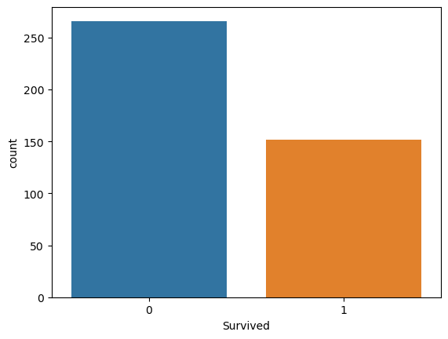

```python
sns.countplot(x='Survived', data=titanic_data)
plt.show()
```

### Male vs Female Survival

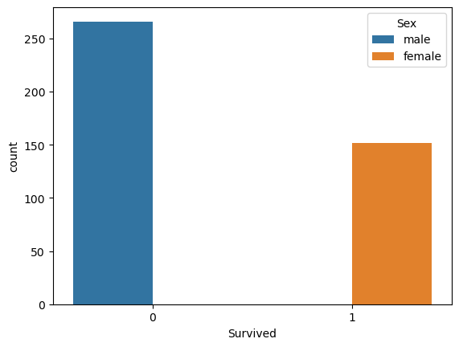

```python
sns.countplot(x='Survived', data=titanic_data, hue='Sex')
plt.show()
```

Only Females are Survived and Male are not Survived as per the countplot

### Check for null

```python
titanic_data.isna()
```

|  | PassengerId | Survived | Pclass | Name | Sex | Age | SibSp | Parch | Ticket | Fare | Cabin | Embarked |
| --- | --- | --- | --- | --- | --- | --- | --- | --- | --- | --- | --- | --- |
| 0 | False | False | False | False | False | False | False | False | False | False | True | False |
| 1 | False | False | False | False | False | False | False | False | False | False | True | False |
| 2 | False | False | False | False | False | False | False | False | False | False | True | False |
| 3 | False | False | False | False | False | False | False | False | False | False | True | False |
| 4 | False | False | False | False | False | False | False | False | False | False | True | False |
| ... | ... | ... | ... | ... | ... | ... | ... | ... | ... | ... | ... | ... |
| 413 | False | False | False | False | False | True | False | False | False | False | True | False |
| 414 | False | False | False | False | False | False | False | False | False | False | False | False |
| 415 | False | False | False | False | False | False | False | False | False | False | True | False |
| 416 | False | False | False | False | False | True | False | False | False | False | True | False |
| 417 | False | False | False | False | False | True | False | False | False | False | True | False |

418 rows × 12 columns

### Check how many values are null

```python
titanic_data.isna().sum()
```

```
PassengerId      0
Survived         0
Pclass           0
Name             0
Sex              0
Age             86
SibSp            0
Parch            0
Ticket           0
Fare             1
Cabin          327
Embarked         0
dtype: int64
```

### Visualize null values help of Heatmap

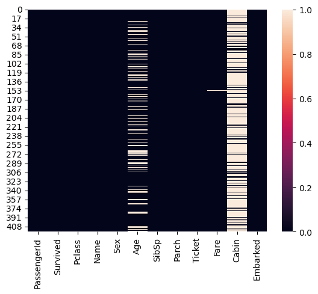

```python
sns.heatmap(titanic_data.isna())
plt.show()
```

### find the % of null values in age column

```python
(titanic_data['Age'].isna().sum()/len(titanic_data['Age']))*100
```

```
20.574162679425836
```

### find the % of null values in cabin column

```python
(titanic_data['Cabin'].isna().sum()/len(titanic_data['Cabin']))*100
```

```
78.22966507177034
```

### find the distribution for the age column

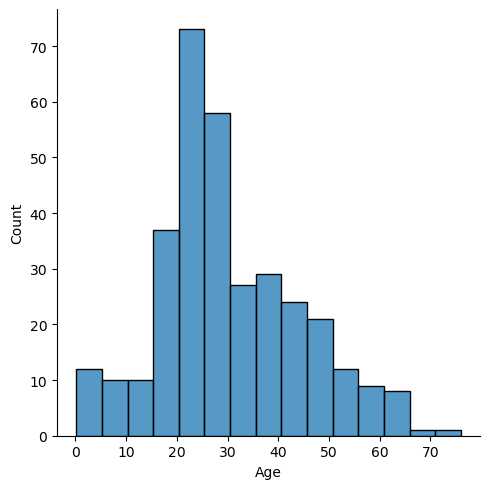

```python
sns.displot(x='Age', data=titanic_data)
plt.show()
```

# Data Cleaning

**Fill the missing values**</BR> we will find the missing values for age. In order to fill missing values we use fillna method.</BR> For now we will fill the missing age by taking average of all age.

### fill age column

```python
titanic_data['Age'].fillna(titanic_data['Age'].mean(), inplace=True)
```

### verify null values

```python
titanic_data['Age'].isna().sum()
```

```
0
```

**Alternatively we will visualise the null value using heatmap.**</BR> we will use heatmap method by passing only records which are null.

```python
#visualize null values again
```

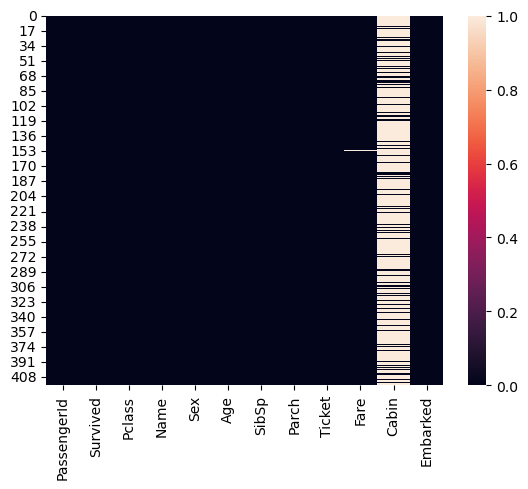

```python
sns.heatmap(titanic_data.isna())
plt.show()
```

**we can see the cabin column has a number of null values, as such we can not use it for prediction. Hence we will drop it.**

```python
#drop cabin column
```

```python
titanic_data.drop('Cabin', axis=1, inplace=True)
```

```python
#see the content of data
```

```python
titanic_data.head()
```

|  | PassengerId | Survived | Pclass | Name | Sex | Age | SibSp | Parch | Ticket | Fare | Embarked |
| --- | --- | --- | --- | --- | --- | --- | --- | --- | --- | --- | --- |
| 0 | 892 | 0 | 3 | Kelly, Mr. James | male | 34.5 | 0 | 0 | 330911 | 7.8292 | Q |
| 1 | 893 | 1 | 3 | Wilkes, Mrs. James (Ellen Needs) | female | 47.0 | 1 | 0 | 363272 | 7.0000 | S |
| 2 | 894 | 0 | 2 | Myles, Mr. Thomas Francis | male | 62.0 | 0 | 0 | 240276 | 9.6875 | Q |
| 3 | 895 | 0 | 3 | Wirz, Mr. Albert | male | 27.0 | 0 | 0 | 315154 | 8.6625 | S |
| 4 | 896 | 1 | 3 | Hirvonen, Mrs. Alexander (Helga E Lindqvist) | female | 22.0 | 1 | 1 | 3101298 | 12.2875 | S |

**Preaparing Data for Model**</BR> No we will require to convert all non-numerical columns to numeric. Please note this is required for feeding data into model. Lets see which columns are non numeric info describe method

```python
#Check for the non-numeric column
```

```python
titanic_data.info()
```

```
<class 'pandas.core.frame.DataFrame'>
RangeIndex: 418 entries, 0 to 417
Data columns (total 11 columns):
 #   Column       Non-Null Count  Dtype
---  ------       --------------  -----
 0   PassengerId  418 non-null    int64
 1   Survived     418 non-null    int64
 2   Pclass       418 non-null    int64
 3   Name         418 non-null    object
 4   Sex          418 non-null    object
 5   Age          418 non-null    float64
 6   SibSp        418 non-null    int64
 7   Parch        418 non-null    int64
 8   Ticket       418 non-null    object
 9   Fare         417 non-null    float64
 10  Embarked     418 non-null    object
dtypes: float64(2), int64(5), object(4)
memory usage: 36.0+ KB
```

```python
titanic_data.dtypes
```

```
PassengerId      int64
Survived         int64
Pclass           int64
Name            object
Sex             object
Age            float64
SibSp            int64
Parch            int64
Ticket          object
Fare           float64
Embarked        object
dtype: object
```

**We can see, Name, Sex, Ticket and Embarked are non-numerical.It seems Name,Embarked and Ticket number are not useful for Machine Learning Prediction hence we will eventually drop it. For Now we would convert Sex Column to dummies numerical values****

```python
#convert sex column to numerical values
```

```python
gender=pd.get_dummies(titanic_data['Sex'],drop_first=True)
```

```python
titanic_data['Gender']=gender
```

```python
titanic_data.head()
#Here, in Gender male=1 & female=0
```

|  | PassengerId | Survived | Pclass | Name | Sex | Age | SibSp | Parch | Ticket | Fare | Embarked | Gender |
| --- | --- | --- | --- | --- | --- | --- | --- | --- | --- | --- | --- | --- |
| 0 | 892 | 0 | 3 | Kelly, Mr. James | male | 34.5 | 0 | 0 | 330911 | 7.8292 | Q | 1 |
| 1 | 893 | 1 | 3 | Wilkes, Mrs. James (Ellen Needs) | female | 47.0 | 1 | 0 | 363272 | 7.0000 | S | 0 |
| 2 | 894 | 0 | 2 | Myles, Mr. Thomas Francis | male | 62.0 | 0 | 0 | 240276 | 9.6875 | Q | 1 |
| 3 | 895 | 0 | 3 | Wirz, Mr. Albert | male | 27.0 | 0 | 0 | 315154 | 8.6625 | S | 1 |
| 4 | 896 | 1 | 3 | Hirvonen, Mrs. Alexander (Helga E Lindqvist) | female | 22.0 | 1 | 1 | 3101298 | 12.2875 | S | 0 |

```python
#drop the column which are not require
```

```python
titanic_data.drop(['Name','Sex','Ticket','Embarked'], axis=1, inplace=True)
```

```python
titanic_data.head()
```

|  | PassengerId | Survived | Pclass | Age | SibSp | Parch | Fare | Gender |
| --- | --- | --- | --- | --- | --- | --- | --- | --- |
| 0 | 892 | 0 | 3 | 34.5 | 0 | 0 | 7.8292 | 1 |
| 1 | 893 | 1 | 3 | 47.0 | 1 | 0 | 7.0000 | 0 |
| 2 | 894 | 0 | 2 | 62.0 | 0 | 0 | 9.6875 | 1 |
| 3 | 895 | 0 | 3 | 27.0 | 0 | 0 | 8.6625 | 1 |
| 4 | 896 | 1 | 3 | 22.0 | 1 | 1 | 12.2875 | 0 |

```python
titanic_data.isna().sum()
```

```
PassengerId    0
Survived       0
Pclass         0
Age            0
SibSp          0
Parch          0
Fare           1
Gender         0
dtype: int64
```

```python
# Fill null value with average in Fare Column
titanic_data['Fare'].fillna(titanic_data['Fare'].mean(), inplace=True)
```

```python
#Seperate Dependent and Independent variables
```

```python
x=titanic_data[['PassengerId','Pclass','Age','SibSp','Parch','Fare','Gender']]
y=titanic_data['Survived']
```

```python
x
```

|  | PassengerId | Pclass | Age | SibSp | Parch | Fare | Gender |
| --- | --- | --- | --- | --- | --- | --- | --- |
| 0 | 892 | 3 | 34.50000 | 0 | 0 | 7.8292 | 1 |
| 1 | 893 | 3 | 47.00000 | 1 | 0 | 7.0000 | 0 |
| 2 | 894 | 2 | 62.00000 | 0 | 0 | 9.6875 | 1 |
| 3 | 895 | 3 | 27.00000 | 0 | 0 | 8.6625 | 1 |
| 4 | 896 | 3 | 22.00000 | 1 | 1 | 12.2875 | 0 |
| ... | ... | ... | ... | ... | ... | ... | ... |
| 413 | 1305 | 3 | 30.27259 | 0 | 0 | 8.0500 | 1 |
| 414 | 1306 | 1 | 39.00000 | 0 | 0 | 108.9000 | 0 |
| 415 | 1307 | 3 | 38.50000 | 0 | 0 | 7.2500 | 1 |
| 416 | 1308 | 3 | 30.27259 | 0 | 0 | 8.0500 | 1 |
| 417 | 1309 | 3 | 30.27259 | 1 | 1 | 22.3583 | 1 |

418 rows × 7 columns

```python
y
```

```
0      0
1      1
2      0
3      0
4      1
      ..
413    0
414    1
415    0
416    0
417    0
Name: Survived, Length: 418, dtype: int64
```

# Data Modeling

**Building Model using Logistic Regression**</BR> </BR> **Build the model**

```python
#import train test split method
```

```python
from sklearn.model_selection import train_test_split
```

```python
#train test split
```

```python
X_train, X_test, y_train, y_test = train_test_split(x, y, test_size=0.33, random_state=42)
```

```python
#import logistic Regression
```

```python
from sklearn.linear_model import LogisticRegression
```

```python
#fit Logistic Regression
```

```python
lr = LogisticRegression()
```

```python
lr.fit(X_train,y_train)

# Ignoring errors
import warnings
warnings.filterwarnings('ignore')
```

```python
#predict
```

```python
predict=lr.predict(X_test)
```

# Testing

**See how our model is performing**

```python
#print confusion matrix
```

```python
from sklearn.metrics import confusion_matrix
```

```python
pd.DataFrame(confusion_matrix(y_test,predict),columns=['Predicted No','Predicted Yes'],
             index=['Actual No','Actual Yes'])
```

|  | Predicted No | Predicted Yes |
| --- | --- | --- |
| Actual No | 92 | 0 |
| Actual Yes | 0 | 46 |

```python
#import classification report
```

```python
from sklearn.metrics import classification_report
```

```python
print(classification_report(y_test, predict))
```

```
              precision    recall  f1-score   support

           0       1.00      1.00      1.00        92
           1       1.00      1.00      1.00        46

    accuracy                           1.00       138
   macro avg       1.00      1.00      1.00       138
weighted avg       1.00      1.00      1.00       138
```

Note:</BR> Precision : Precision is the ratio of correctly predicted positive observations to the total predicted positive observations Recall : Recall is the ratio of correctly predicted positive observations to the all observations in actual class F1 score - F1 Score is the weighted average of Precision and Recall.

# THANK YOU!!!

### GitHub: https://github.com/anujtiwari21?tab=repositories